## START DRAFTING FIRST LESSON HERE

THIS BIG CODE CHUNK IS THE CLASS SIZE SCRIPT DEMO I WROTE MAY14

```r
# ***this chunk not evaluated***

# location of class size demo script
setwd("../../demos/demo_classsize/")
# location of this doc
setwd("../../slides/rmc_week1/")
```

```r
source("../../demos/demo_classsize/demo_classsize.r", echo=TRUE)
```

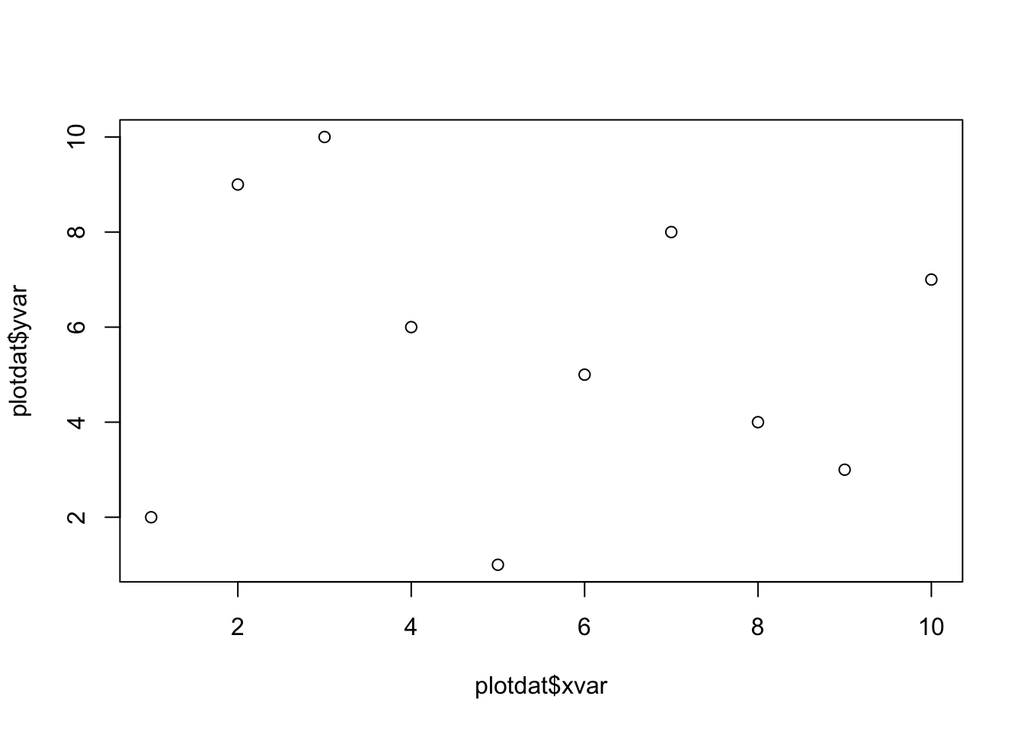

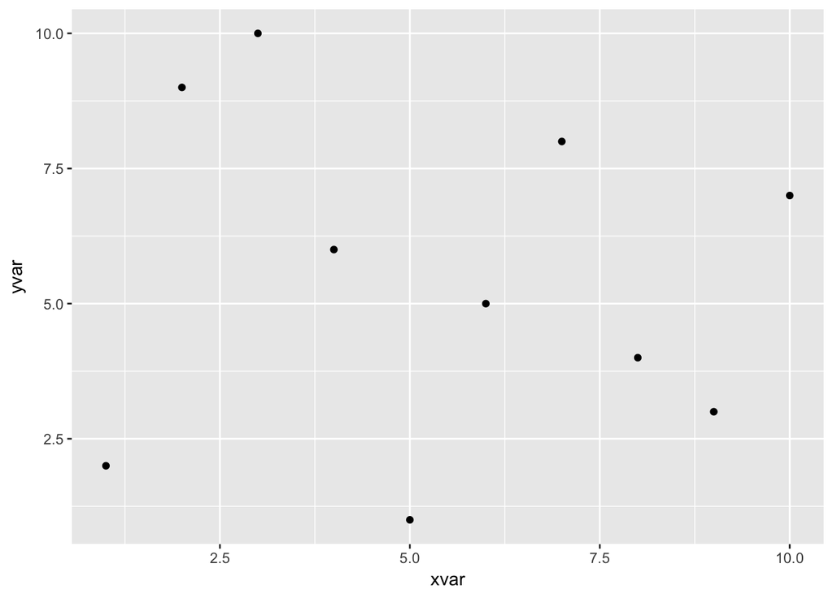

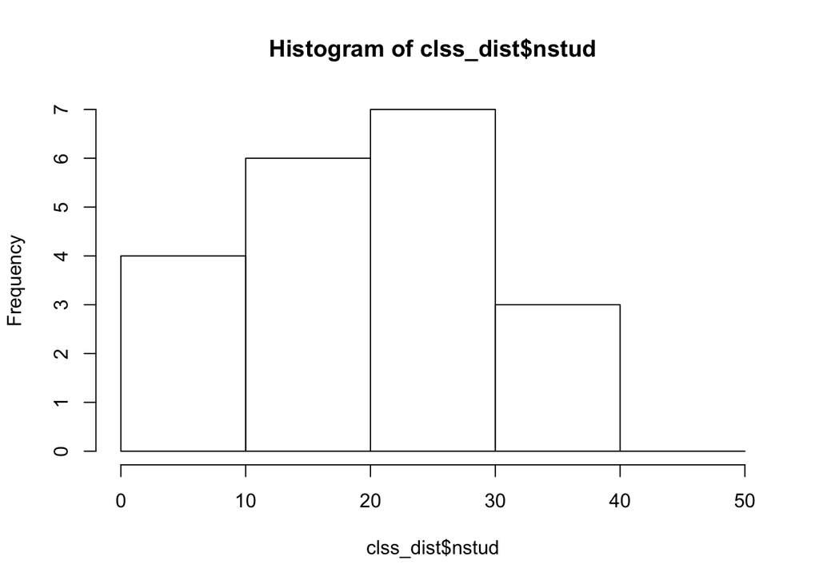

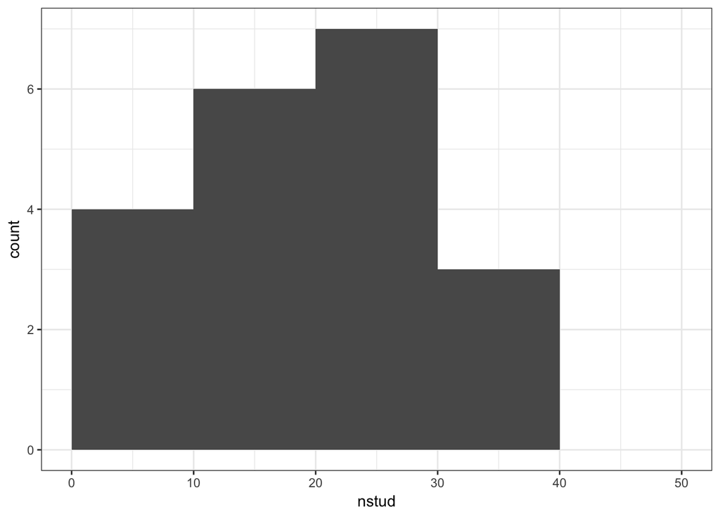

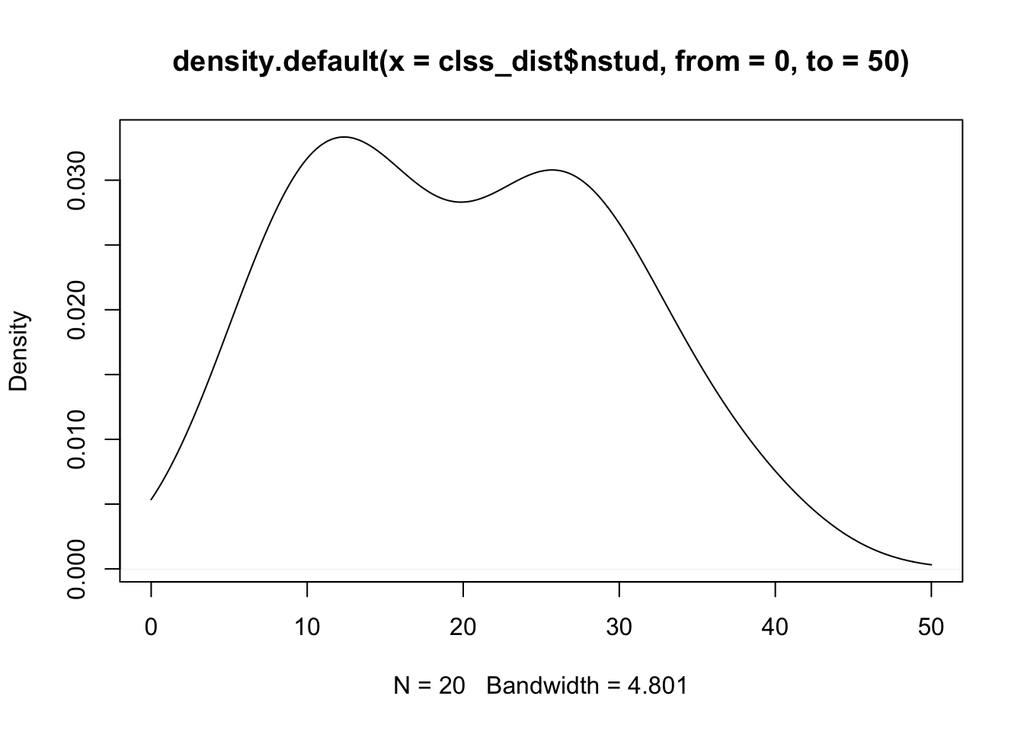

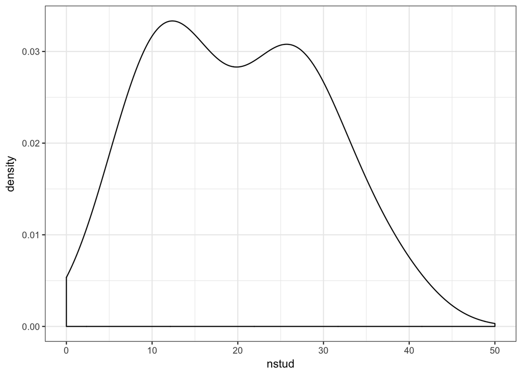

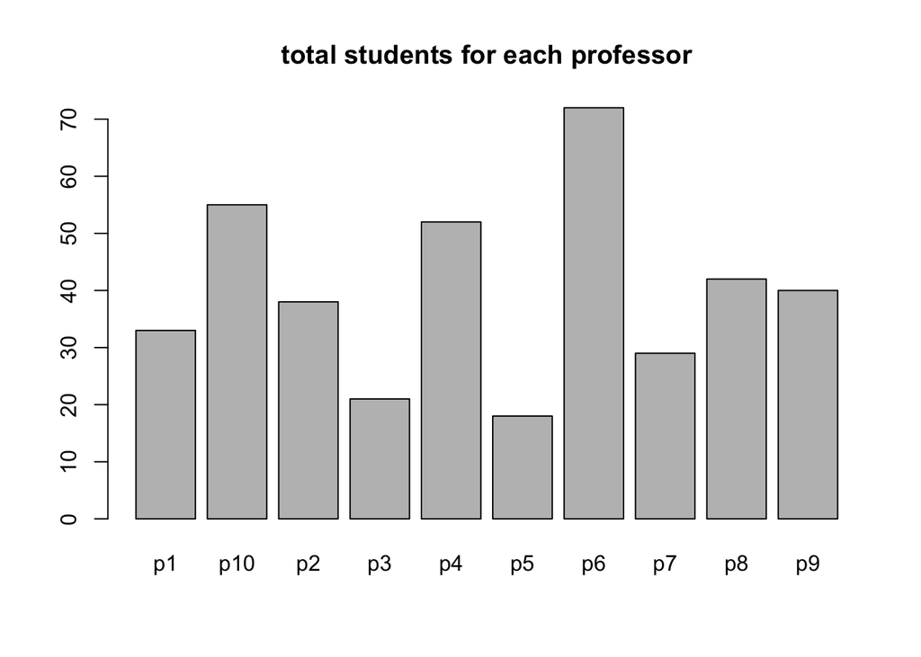

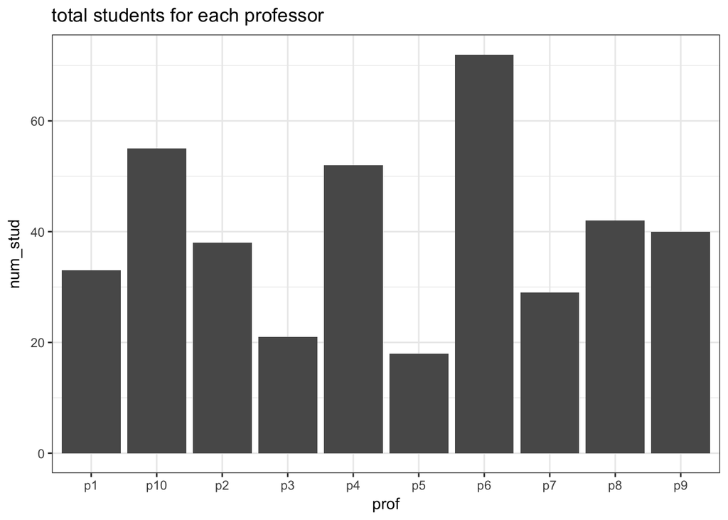

```
##
## > knitr::opts_chunk$set(results = "hold", message = FALSE,
## +     out.width = 450, fig.show = "hold")
##
## > library("magrittr")
##
## > library("dplyr")
##
## > library("ggplot2")
##
## > round_up <- function(x, to = 10) {
## +     to * (x%/%to + ifelse(x%%to != 0, 1, 0))
## + }
##
## > nprof <- 10
##
## > nstud <- 100
##
## > nclss <- 20
##
## > nteach <- nclss/nprof
##
## > ntake <- 4
##
## > prof <- paste0("p", seq_len(nprof))
##
## > stud <- paste0("s", seq_len(nstud))
##
## > clss <- paste0("c", seq_len(nclss))
##
## > profclss <- data.frame(prof = rep(prof, times = nteach),
## +     clss = rep(clss, length.out = nprof * nteach), stringsAsFactors = FALSE)
##
## > studclss <- data.frame(stud = rep(stud, times = ntake),
## +     clss = c(clss, sample(clss, size = (nstud * ntake) - nclss,
## +         replace = TRUE .... [TRUNCATED]
##
## > dupes <- which(duplicated(studclss))
##
## > if (length(dupes) == 0) {
```

[output cut: 97 more lines]

```
## > hist(clss_dist$nstud, breaks = seq(0, 50, by = 10))
##
## > ggplot(clss_dist) + geom_histogram(aes(x = nstud),
## +     breaks = seq(0, 50, by = 10))
##
## > plot(density(clss_dist$nstud, from = 0, to = 50))
##
## > ggplot(clss_dist) + geom_density(aes(x = nstud)) +
## +     scale_x_continuous(limits = c(0, 50))
##
## > barplot(height = profstats$num_stud, names.arg = profstats$prof,
## +     main = "total students for each professor")
##
## > ggplot(profstats, aes(x = prof, y = num_stud)) + geom_bar(stat = "identity") +
## +     labs(title = "total students for each professor")
```

BELOW HERE IS TUTORIAL FROM PSYCHOLING AU16

## hello world

R works with an interpreter, which means that you can **run**/**execute** a single command at a time, where a “command” is just a **line** or **block** of code. To “run” a region of code is to send it to the interpreter.

Lines that start with `#` are **comments**, and are intended to be interpreted by other humans (especially your future self). Comments are ignored by the interperter.

When you run a command, the output (if there’s any) will appear in the **console**, for which there’s a separate pane in RStudio.

The way we’ll run R code in this course is **interactively**, meaning that you have an R script (i.e. a file with extension `.r` or `.R`), you write a command in the script file, send it to the interpreter, inspect the result, and then decide what to type/evaluate next. This is also known as a **REPL** programming environment, for **R**ead-**E**val-**P**rint **L**oop. We’ll see at least one example of calling R code in a non-REPL environment later in the course.

## first commands

Our first command is a true classic – `3 + 5`. Execute it with **cmd+Enter** on Mac, or **ctrl+Enter** on PC.

```r
3 + 5
```

```
## [1] 8
```

The output indicates that the first (and only) element `"[1]"` of the output is `8`, so the interpreter **returned** the number `8` given the command `5 + 3`. That seems about right.

We can do all kinds of mathematical calculations, e.g.

```r
3 + ((1 - (5 * 2)) / (3 ^ 2))
```

```
## [1] 2
```

In R, `+`, `*`, `/`, etc. are **functions**, and the things they link together are their **arguments**. The thing (note singular *thing*) that a function returns when it’s applied to arguments is its **value**.

But almost all functions in R have a different syntax – they take their arguments in a more function-y notation (’member “f(x)” from high school math?). for example `sqrt()` takes one argument (a number) and returns the square root of that argument:

```r
sqrt(9)
```

```
## [1] 3
```

The functions `max()` and `min()` can take any number of arguments, and return the highest/lowest of them:

```r
max(1, 2, 3, 5, 4, 5, 6, 6, -10)
min(1, 2, 3, 5, 4, 5, 6, 6, -10)
```

```
## [1] 6
## [1] -10
```

You can always pull up the help page for a function by saying `?<function-name>()`. you can search help pages with `??<topic>`

```r
?max()
??linguistics
```

One of the best things about R is that anyone can contribute helfpul collections of new functions and other stuff designed for particular kinds of tasks (after a thorough review process by the R Core Team!). These are bundled in **packages**, and give you access to capabilities that aren’t part of what automatically comes with R when you install it (aka **base R**).

For example `lme4::` is an excellent package for mixed-effects/multilevel regression models, the `ggplot2::` package is probably the best statistical graphics framework around, and `dplyr::` contains functions for optimizing data cleaning and transformation pipelines. We’ll use the latter two extensively in this course.

If you are using a particular package for the first time, you will have to install it, which can be done with `install.packages("<package name>")` (note quotes around the name, which are necessary when installing).

```r
install.packages("languageR")
```

Unless you update your R version, or the author of the package releases a new version, you only need to install a package once.

To use a package you’ve installed, load it with `library()`

```r
library("languageR")
```

Note on unfortunate terminology: in R, a **library** is a collection of installed packages, but you load an individual package using the `library()` function.

You can see your library – a list of your installed packages – by saying `library()` *without* an argument. You can see which packages are currently **loaded** with `search()`, again with no argument.

## variables and assignments

Most of the time we don’t just want to calculate something, but we want to calculate something and **store** the result for later use. We do this by **assigning** the result of a command to a **variable** such as `x` by using the **assignment** operator `<-`

```r
x <- 5 + 3
```

Notice in the upper right pane of RStudio, you can now see `x` is saved. We can look at the **value** of the variable `x` by simply sending `x` to the interpreter (sometimes you’ll see people wrap `x` in `print()` as below, which is almost always equivalent)

```r
# display whatever x's value is
x
# does the same thing
print(x)
```

```
## [1] 8
## [1] 8
```

We can store the results of basically any computation in a variable, and we can (*and should*) use useful names for variables

```r
biggest <- max(1, 2, 3, 4, 5, 6, 7, 8, 9, 10)
biggest
```

```
## [1] 10
```

A lot of times it makes sense to have a variable name with two words. If you want to do that, you can separate the words with underscores – as in `my_variable`, `biggest_num`, etc. – or use “camel case”, as in `myVariable` or `biggestNum`.

Make sure your variable names don’t contain math operators like `-` or `+`, and make sure they don’t start with a number: we can name a var `var1`

```r
var1 <- 1 + 1
```

But not `1stVar`, because it starts with a number:

```r
# if we try:
#   1stVar = 1 + 1

# we will get:
#   Error: unexpected symbol in "1stVar"
```

Errors and error messages are annoying but extremely important + useful! More on those later.

To avoid clutter and reduce memory load, we can remove variables from the workspace when we are done working with them by using `rm()`.

```r
rm(var1)
rm(biggest)
rm(x)
```

A common pitfall is to confuse `=` (argument binding) with `==` (equals).

```r
# if we try:
#   5 + 3 = 8

# we will get:
#   Error in 5 + 3 = 8 : target of assignment expands to non-language object
```

To say what we meant, we would use `==`. Since `5 + 3 == 8` is a “sentence” (in that it’s a true or false statement), the value it returns is the **boolean**/**logical** value TRUE. A false arithmetic statement will return – you guessed it – the boolean value FALSE.

```r
5 + 3 == 8
5 + 3 == 9
```

```
## [1] TRUE
## [1] FALSE
```

To say that two values are *not* equal, you can use `!=`. We’ll go further into working with boolean values in a later class.

```r
5 + 3 != 8
5 + 3 != 9
```

```
## [1] FALSE
## [1] TRUE
```

## data types and data structures

The sense we use “data” in here is the computer-y one.

```r
x <- 5
class(x)
typeof(x)
```

```
## [1] "numeric"
## [1] "double"
```

let’s give x a new value + see its type (character string)

```r
x <- "boosh"
class(x)
typeof(x)
```

```
## [1] "character"
## [1] "character"
```

`logical` (true/false; binary) is also a basic data type:

```r
x <- TRUE
class(x)
typeof(x)
```

```
## [1] "logical"
## [1] "logical"
```

Usually we work with more complicated **data structures** than just individual strings or numbers. The most commonly used data structure in R is the **vector**, which is just a sequence of values that share a common type (e.g. `c(1,2,"a")` is not a well-formed vector). Vectors are formed by feeding an arbitrary number of comma-separated values to the concatenate function `c()`.

```r
# a vector is built with c()
vec1 <- c("boosh1","boosh2","boosh3")
vec2 <- c(1,2,3)
vec1
vec2
```

```
## [1] "boosh1" "boosh2" "boosh3"
## [1] 1 2 3
```

Lists are kind of like vectors, but the types of the elements don’t have to be uniform. For example both of the following are valid lists.

```r
# a list is built with list()
lis1 <- list("boosh1","boosh2","boosh3")
lis2 <- list("boosh1",2,"boosh3",4)
lis2
```

```
## [[1]]
## [1] "boosh1"
##
## [[2]]
## [1] 2
##
## [[3]]
## [1] "boosh3"
##
## [[4]]
## [1] 4
```

Lists and vectors are *not* the same thing:

```r
identical(vec1,lis1)
```

```
## [1] FALSE
```

There are other important differences, which we’ll get into later.

The data structure for which R is well-known is called the **data frame**, which you can think of as basically just a spreadsheet. We can define a data frame as a series of vectors, each of which is like a column. When we define a dataframe, we can name the columns (as in `df2`), but we don’t have to (as in `df1`).

```r
df1 <- data.frame(vec1, vec2)
df1

df2 <- data.frame(
  col1=c("a","b","c","d","e","f"),
  col2=c(1,2,3,4,5,6),
  col3=rep(c("g1","g2"), times=3)
)
df2
```

```
##     vec1 vec2
## 1 boosh1    1
## 2 boosh2    2
## 3 boosh3    3
##   col1 col2 col3
## 1    a    1   g1
## 2    b    2   g2
## 3    c    3   g1
## 4    d    4   g2
## 5    e    5   g1
## 6    f    6   g2
```

Note the use of `rep()`, which repeats its first argument the number of time specified by its second argument. This illustrates the important fact that argument places have **names**, e.g. the function `rep()` has an argument called `times`, which indicates the number of times that the first argument to `rep()` should be repeated. We saturated `times` with `3` above, yielding a vector of length `6`. When there’s no risk of ambiguity, often times the argument position name will be dropped (so you’d see e.g. `rep(c("g1","g2"), 3)` instead).

The columns of a data frame must all be the same length. You can find the length of a vector by calling `length()` on it.

```r
length(vec1)
```

```
## [1] 3
```

A `data.frame()` is in fact a list of vectors `v1`,`v2`,…,`vn` such that `length(v1)==length(v2)==`…`==length(vn)`

```r
is.list(df1)
is.data.frame(df1)
```

```
## [1] TRUE
## [1] TRUE
```

But you should think of a dataframe as a spreadsheet that contains **data**, usually where each row is a sequence of facts about a single thing

```r
df2
```

```
##   col1 col2 col3
## 1    a    1   g1
## 2    b    2   g2
## 3    c    3   g1
## 4    d    4   g2
## 5    e    5   g1
## 6    f    6   g2
```

Now let’s clean up the workspace before moving on (doing this saves memory + can help keep your agenda clear). Instead of starting a new line, we can indicate the end of a command with `;`

```r
rm(df1); rm(df2); rm(lis1); rm(lis2); rm(vec1); rm(vec2); rm(x)
```

## Section 4: Data frames and reading files

Let’s check out the frequency list we used for homework #4. We’ll read it in with `read.csv()` and store it in a var called `words`.

```r
words <- read.csv(
  "http://lefft.xyz/r_minicourse/datasets/top5k-word-frequency-dot-info.csv",
  sep=",", header=TRUE
)
```

`read.csv()` gives us a data frame (henceforth df).

```r
class(words)
```

```
## [1] "data.frame"
```

The first thing we should do when reading in a new df is check it out

```r
# see the structure of the df -- info on each column
str(words)
# get a summary of each col of the df
summary(words)
```

```
## 'data.frame':    5000 obs. of  5 variables:
##  $ Rank        : int  1 2 3 4 5 6 7 8 9 10 ...
##  $ Word        : Factor w/ 4352 levels "a","abandon",..: 3911 340 160 2605 1 1961 3972 1806 3972 2100 ...
##  $ PartOfSpeech: Factor w/ 14 levels "a","c","d","e",..: 1 13 2 5 1 5 11 13 5 9 ...
##  $ Frequency   : int  22038615 12545825 10741073 10343885 10144200 6996437 6332195 4303955 3856916 3872477 ...
##  $ Dispersion  : num  0.98 0.97 0.99 0.97 0.98 0.98 0.98 0.97 0.99 0.96 ...
##       Rank           Word       PartOfSpeech    Frequency
##  Min.   :   1   like   :   5   n      :2542   Min.   :    4875
##  1st Qu.:1251   no     :   5   v      :1001   1st Qu.:    7723
##  Median :2500   light  :   4   j      : 839   Median :   13698
##  Mean   :2500   past   :   4   r      : 340   Mean   :   65959
##  3rd Qu.:3750   top    :   4   i      :  97   3rd Qu.:   31474
##  Max.   :5000   as     :   3   p      :  46   Max.   :22038615
##                 (Other):4975   (Other): 135
##    Dispersion
##  Min.   :0.4700
##  1st Qu.:0.9200
##  Median :0.9400
##  Mean   :0.9324
##  3rd Qu.:0.9500
##  Max.   :0.9900
##
```

we can also look at the first n rows by calling head() and specifying n

```r
head(words, n=5)
```

```
##   Rank Word PartOfSpeech Frequency Dispersion
## 1    1  the            a  22038615       0.98
## 2    2   be            v  12545825       0.97
## 3    3  and            c  10741073       0.99
## 4    4   of            i  10343885       0.97
## 5    5    a            a  10144200       0.98
```

*in RStudio only* we can use `View()` to see the whole thing in a window (can also click on the df in the upper righthand pane)

```r
View(words)
```

## Section 5: Basic operations on data frames

The individual cols of a df are referred to “variables” (confusing, ik!) and they can be accessed by name with the `$` operator

```r
wordCol <- words$Word
```

Just view the first 10 elements of a vector with `<vec-name>[1:10]`

```r
wordCol[1:10]
rm(wordCol)
```

```
##  [1] the  be   and  of   a    in   to   have to   it
## 4352 Levels: a abandon ability able abortion about above abroad ... zone
```

We can access a row or range of rows using the `[ , ]` operator (for rows, before the comma)

```r
words[1:2,]
```

```
##   Rank Word PartOfSpeech Frequency Dispersion
## 1    1  the            a  22038615       0.98
## 2    2   be            v  12545825       0.97
```

Also works for cols (after the comma)

```r
head(words[,1:2], n=5)
```

```
##   Rank Word
## 1    1  the
## 2    2   be
## 3    3  and
## 4    4   of
## 5    5    a
```

We can add new cols by combining `$` with the assignment operator

```r
words$newCol <- words$Frequency / words$Rank
head(words, n=5)
```

```
##   Rank Word PartOfSpeech Frequency Dispersion   newCol
## 1    1  the            a  22038615       0.98 22038615
## 2    2   be            v  12545825       0.97  6272912
## 3    3  and            c  10741073       0.99  3580358
## 4    4   of            i  10343885       0.97  2585971
## 5    5    a            a  10144200       0.98  2028840
```

we can remove cols we no longer need or don’t want by assigning them to `NULL`

```r
words$newCol <- NULL
```

We can also change the data type of a given col. `words$PartOfSpeech` is a **factor**, meaning a discrete category with a specified set of possible values – i.e. **levels**

```r
class(words$PartOfSpeech)
levels(words$PartOfSpeech)
```

```
## [1] "factor"
##  [1] "a" "c" "d" "e" "i" "j" "m" "n" "p" "r" "t" "u" "v" "x"
```

We could change p.o.s. to character type with

```r
words$PartOfSpeech <- as.character(words$PartOfSpeech)
```

```r
class(words$PartOfSpeech)
```

```
## [1] "character"
```

But we should change it back because p.o.s. actually is a factor

```r
words$PartOfSpeech <- as.factor(words$PartOfSpeech)
```

It is often useful to **subset** a df if we are interested in only some part of it – usually some subset of the rows. Suppose we only want to look at info about the 100 most frequent words. We could carve out the top 100 by saying any of the following:

```r
frequentWords <- subset(words, Rank %in% 1:100)
frequentWords <- subset(words, Rank < 101)
frequentWords <- subset(words, Rank <= 100)
```

There are several functions that can be used for subsetting we can also use a more primitive (but safer + ultimately better) way:

```r
frequentWords <- words[words$Rank %in% 1:100, ]
frequentWords <- words[words$Rank < 101, ]
frequentWords <- words[words$Rank <= 100, ]
rm(frequentWords)
```

You can see that these methods yield the same result:

```r
identical(subset(words, Rank < 101), words[words$Rank < 101, ])
```

```
## [1] TRUE
```

Now suppose we only want to look at nouns. then we could define `nouns` as

```r
nouns <- subset(words, PartOfSpeech=="n")
```

Here is a **tricky** fact: when you subset a df, you retain all original factor levels, even if they aren’t instantiated in the subset

```r
levels(nouns$PartOfSpeech)
levels(nouns$Word)[1:10]
```

```
##  [1] "a" "c" "d" "e" "i" "j" "m" "n" "p" "r" "t" "u" "v" "x"
##  [1] "a"        "abandon"  "ability"  "able"     "abortion" "about"
##  [7] "above"    "abroad"   "absence"  "absolute"
```

We usually want to eliminate factor levels that do not occur in the subset:

```r
nouns <- droplevels(nouns)
```

You can also wrap `subset()` with `droplevels()` in the subsetting call itself:

```r
nouns <- droplevels(subset(words, PartOfSpeech=="n"))
```

## Section 6: summary statistics and visualizing data

We can get the average of a numeric vector (incl. a df column) using `mean()`

```r
mean(words$Rank)
```

```
## [1] 2500.5
```

Sometimes df’s will have **missing values**, indicated with `NA` if we try to take the mean of a vector containing `NA`, we get `NA` as a result, even if 99% of the vector has legitimate numbers in it.

```r
mean(c(1,2,3,NA))
```

```
## [1] NA
```

So it is often safest to set the na.rm argument to `TRUE`, as in:

```r
mean(c(1,2,3,NA), na.rm=TRUE)
```

```
## [1] 2
```

We can also see more detailed info of a col with `summary()`

```r
summary(words$Frequency)
```

```
##     Min.  1st Qu.   Median     Mean  3rd Qu.     Max.
##     4875     7723    13698    65959    31474 22038615
```

We can look at a table of a factor col or see a summary

```r
table(words$PartOfSpeech)
```

```
##
##    a    c    d    e    i    j    m    n    p    r    t    u    v    x
##   11   38   34    1   97  839   35 2542   46  340    1   13 1001    2
```

We can look at the distribution of a numeric var with a histogram:

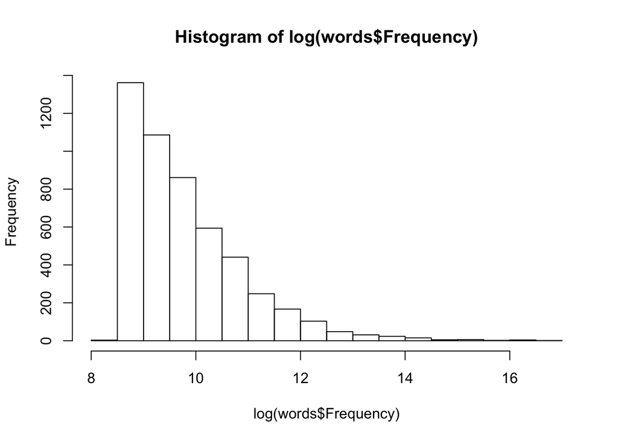

```r
hist(log(words$Frequency)) # easier to see dist if we take log first
```

We can make a scatterplot of two numeric variables.

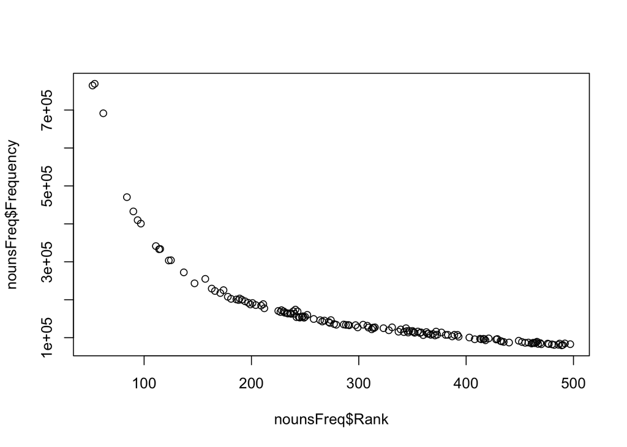

```r
# (easier to see w a subset)
nounsFreq <- subset(nouns, Rank < 500)

plot(nounsFreq$Rank, nounsFreq$Frequency)
```

Waow looks like a strong relationship…Actually, we are looking at a visual example of **Zipf’s Law**!!!

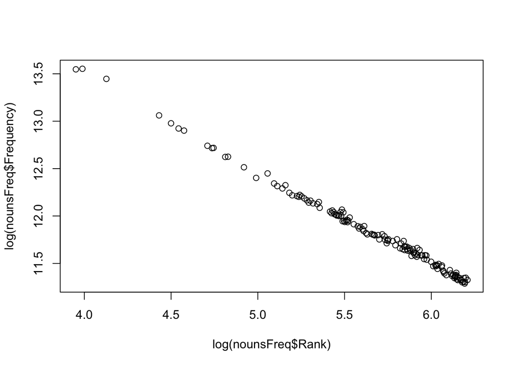

```r
plot(log(nounsFreq$Rank), log(nounsFreq$Frequency))
```

Zipf’s Law states that word-frequency is inversely related to frequency rank – we can see that the linear correlation between frequency and rank is very strong; if we apply a log transformation, the relationship is about as perfect as you will ever see in an empirical domain.

```r
cor(nounsFreq$Rank, nounsFreq$Frequency)
cor(log(nounsFreq$Rank), log(nounsFreq$Frequency))
```

```
## [1] -0.7756254
## [1] -0.9973444
```

End tangent into Zipf’s law.

We can also plot subsets of a numeric variable for each level of a factor

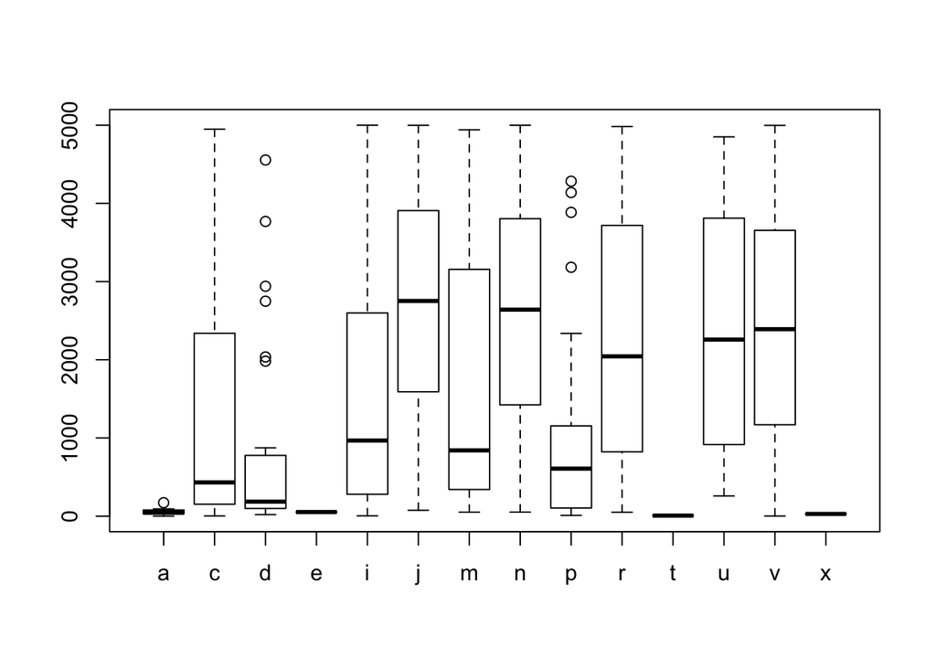

```r
plot(words$PartOfSpeech, words$Rank)
```

This plot is very informative but not very intuitive to read. What about something easier to understand, like a bar graph? Specifically, what would be nice is if for each part of speech, we had a bar whose height is equal to the average rank of words with that part of speech, within our dataset.

To make the visualization more meaningful, let’s cut the df so that it contains only: nouns, verbs, adjectives, prepositions, articles, and pronouns.

```r
nvap <- subset(words, PartOfSpeech %in% c("n","v","j","i","a","p"))
```

There are a number of ways to make the plot we are aiming for. We will do it in a way that will illustrate how to execute another important and common task in R: aggregation. We can use the function `aggregate()` to calculate the mean rank for each subset of the data defined by a level of `nvap$PartOfSpeech` (there are other ways to do this as well). The result of this `aggregate()` call will be a df containing the group means:

```r
meanRanks <- aggregate(Rank ~ PartOfSpeech, FUN="mean", data=nvap)
meanRanks
```

```
##   PartOfSpeech       Rank
## 1            a   58.54545
## 2            i 1581.38144
## 3            j 2720.49464
## 4            n 2613.92132
## 5            p  947.93478
## 6            v 2435.96404
```

Now that we have our means, we can make a plot of them. If you ever get more into R, you will want to use the amazing visualization library `ggplot2::` (for “grammar of graphics”)

And here’s the plot (I won’t explain `ggplot2` syntax here, it is a bit less intuitive than the base graphics capabilities, but well-worth learning).

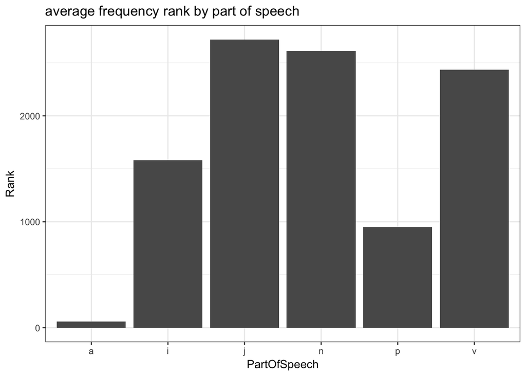

```r
ggplot(data=meanRanks, aes(x=PartOfSpeech,y=Rank)) +
  geom_bar(stat="identity") +
  ggtitle("average frequency rank by part of speech")
```

Interesting…What does the plot tell us about frequency and parts of speech?

```r
# sec 6 cleanup
rm(nvap); rm(meanRanks); rm(nounsFreq); rm(nouns)
```

## Section 7: stuff to know about R syntax

Using `=` for var assignment is actually not a good practice (for reasons you don’t need to understand at this point – ask me if you’re interested)

We *should* be using `<-`, which is unfortunate bc it less obvious + intuitive. The reason is that, while `=` and `<-` have some common uses, both have uses such that, if we use the other one instead, things will break. Ask me more if you are interested.

```r
x <- 5 + 3
```

*However*, you should still use `=` when you are specifying an argument in a function call, e.g. in the following say `n=10`, not `n<-10`

```r
head(words, n=3)
```

```
##   Rank Word PartOfSpeech Frequency Dispersion
## 1    1  the            a  22038615       0.98
## 2    2   be            v  12545825       0.97
## 3    3  and            c  10741073       0.99
```

Generally speaking, spaces and brackets are optional in R, but make code more readable

```r
5+3/2^2-4 == 5 + (3 / 2^2) - 4

identical(x<-5+3, x <- 5 + 3)

identical(max(1, 2, 3), max(1,2,3))
```

```
## [1] TRUE
## [1] TRUE
## [1] TRUE
```

```r
x <- -5+3   # stores -2 in var x
x< -5+3     # gives FALSE!
```

```
## [1] FALSE
```

You can start new lines in the middle of commands too, which sometimes makes for cleaner + easier to read code (note the auto-indenting of RStudio)

```r
theWords <-
  c("theFirstWord","theSecondWord","theThirdWord","theFourthWord",
    "theFifthWord","theSixthWord","theSeventhWord")
```

But again, be careful! If we try the following, we will get an error.

```r
## theWords
##   <-   c("theFirstWord","theSecondWord","theThirdWord","theFourthWord",
##        "theFifthWord","theSixthWord","theSeventhWord")
##
## Error: unexpected ',' in "       "theFifthWord","
```

This next command won’t throw an error, but will insert a newline and tab char into the third element, which we wanted to be `theThirdWord`…

```r
theWords <- c("theFirstWord","theSecondWord","theThird
              Word","theFourthWord",
              "theFifthWord","theSixthWord","theSeventhWord")
```

But instead gets interpreted as:

```r
theWords[3]
```

```
## [1] "theThird\n              Word"
```

It is often useful to organize code into **blocks**, which you can think of as “paragraphs” – groups of sentences/commands that mean/do a single thing. Also good practice to put comments before every block, or even multiple times within a single block.

```r
# this block builds a df of words with their freq's and freq ranks
wordList <- c("w1","w2","w3","w4","w5")
wordFreq <- c(10,4,3,12,12)
wordRank <- rank(-wordFreq, ties.method="min")
wordInfo <- data.frame(
  word=wordList,
  freq=wordFreq,
  rank=wordRank
)

wordInfo
```

```
##   word freq rank
## 1   w1   10    3
## 2   w2    4    4
## 3   w3    3    5
## 4   w4   12    1
## 5   w5   12    1
```

Aaaaand now it’s time to clean up. This is not necessary, but can be comforting if you are a neurotic person :p

```r
rm(x); rm(theWords); rm(wordList); rm(wordFreq); rm(wordRank); rm(wordInfo)
```

That’s all for now, folks! Shoot me an email if you want to talk/learn/hear more!

```r
# want to get inline syntax highlighting
library(highr)
```